# Assignment4

Neve/Viva/Yaohan

2024-04-23

# Introduction

In the 2016 ProPublica article “Machine Bias,” it is found that the recidivism algorithm (a machine learning tool that assigns risk scores of recidivating to individuals) developed by Northpointe was riddled with racial biases, labeling black defendants twice the rate as white defendants as future criminals (ProPublica, 2016). As an increased amount of civic and judicial decisions rely on algorithms these days, the following report has been created per request of the Governor of Georgia to produce an recidivism prediction algorithm that attempts to remove biases.

Evaluation of the model is based on relative tradeoffs between sensitivity and specificity. Sensitivity measures the model’s ability to correctly identify true positives out of all positive cases, while specificity measures the model’s ability to correctly identify true negatives out of all negative cases. They are calculated as:

- `Sensitivity` = True Positive / True Positive + False Negative
- `Specificity` = True Negative / True Negative + False Positive

We recognize that a low sensitivity would imply the model’s underperformance in capturing real recidivating and result in uncaptured social risks. A low specificity, on the other hand, would imply that the model likely overpredicts recidivating risks, which would translate into mislabeling of individuals as potential criminals. Our baseline of assessing the model performance is thus to keep both of the statistics as a satisfactorily high level.

However, according to the formula and ROC curve, sensitivity and specificity generally change in opposite directions as the prediction shifts. By prioritizing sensitivity over specificity, the model’s better ability to capture true criminals would run the risk of increasing misclassification of individuals as future criminals (false positives), thereby resulting in inequity and high judicial expenditures. On the other hand, by prioritizing specificity over sensitivity, while the misclassification error is reduced, the model may let go of true criminals and result in social unrest.

Acknowledging the tradeoffs, our study decides to prioritize sensitivity. However, we carefully evaluate sensitivity increase over specificity decrease, so that we could maximize the model’s ability to capture true criminals while limiting false positive incidents of misclassification.

# Plot of Variables

We selected the following dependent and categorical variables to build the model and conducted exploratory plots, respectively visualizing share and frequency (value of counts) of non-recidivism and recidivism by categories.

**Dependent Variable:**

- Recidivism_Within_3years: recoded as “FALSE” = 0, “TRUE” = 1

**Categorical Variables:**

```r
# Recode dependent variable and reclassify categorical variables
dat <- dat %>%
  mutate(Recidivism_Within_3years = as.character(Recidivism_Within_3years)) %>%
  mutate(Recidivism_Within_3years = as.factor(recode(Recidivism_Within_3years,
    `FALSE` = "0",
    `TRUE` = "1"))) %>%
  mutate(Education_Level = factor(case_when(
    Education_Level %in% c('At least some college') ~ 'At least some college',
    Education_Level %in% c('Less than HS diploma', 'High School Diploma') ~ 'High School or Less'),
    levels = c('High School or Less', 'At least some college'))) %>%
  mutate(Prior_Arrest_Episodes_Felony = factor(case_when(
    Prior_Arrest_Episodes_Felony %in% c('0', '1', '2') ~ '0-2',
    Prior_Arrest_Episodes_Felony %in% c('3', '4', '5', '6', '7', '8', '9') ~ '3 to 9',
    Prior_Arrest_Episodes_Felony %in% c('10 or more') ~ '10 or more'),
    levels = c('0-2', '3 to 9', '10 or more'))) %>%
  mutate(Delinquency_Reports = factor(case_when(
    Delinquency_Reports %in% c('0') ~ '0',
    Delinquency_Reports %in% c('1', '2', '3', '4 or more') ~ '1 or more'))) %>%
  mutate(Program_Attendances = factor(case_when(
    Program_Attendances %in% c('0') ~ '0',
    Program_Attendances %in% c('1', '2', '3', '4', '5', '6', '7', '8', '9') ~ '1 to 9',
    Program_Attendances %in% c('10 or more') ~ '10 or more'))) %>%
  mutate(Program_UnexcusedAbsences = factor(case_when(
    Program_UnexcusedAbsences %in% c('0') ~ '0',
    Program_UnexcusedAbsences %in% c('1', '2', '3 or more') ~ '1 or more')))
```

From the following plots of percentage (share) against category, the overall higher share of recidivated individuals contributes to persistent higher percentages of re-offence across all categories of Condition_Cog_Ed, Condition_Other, Delinquency_Report, Dependents, Employment_Exempt, Program_UnexcusedAbsences, and Race. On the other hand, percentage of recidivism is generally higher at lower age levels, lower education levels, male gender group, higher arrest episodes, and lower program attendance rate.

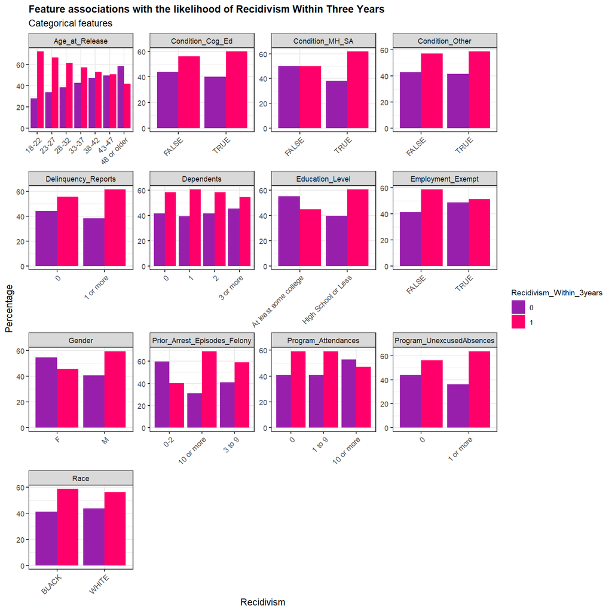

```r
# Plot categorical variables
## Percent
dat %>%
  select(Recidivism_Within_3years,
         Gender,
         Race,
         Age_at_Release,
         Education_Level,
         Dependents,
         Prior_Arrest_Episodes_Felony,
         Condition_MH_SA,
         Condition_Cog_Ed,
         Condition_Other,
         Delinquency_Reports,
         Program_Attendances,
         Program_UnexcusedAbsences,
         Employment_Exempt) %>%
  gather(Variable, value, -Recidivism_Within_3years) %>%
  count(Variable, value, Recidivism_Within_3years) %>%
  group_by(Variable, value) %>%
  mutate(percent = round(n/sum(n)*100, digits = 2)) %>%
  ungroup() %>%
    ggplot(., aes(value, percent, fill = Recidivism_Within_3years)) +
        geom_bar(position = "dodge", stat="identity") +
        facet_wrap(~Variable, ncol = 4, scales="free") +
        scale_fill_manual(values = palette2) +
        labs(x="Recidivism", y="Percentage",
             title = "Feature associations with the likelihood of Recidivism Within Three Years",
             subtitle = "Categorical features") +
        theme_bw() +
  theme(plot.title = element_text(size = 12, face = "bold")) +
  theme(legend.title = element_text(size = 9),
        legend.text = element_text(size = 8)) +
        theme(axis.text.x = element_text(angle = 45, hjust = 1))
```

Patterns observed in the share against category plots are generally verified by the following plots of count value against category. Nonetheless, the count value against category plots indicate that there are distinct category-based sample size differences across different age groups, gender groups, groups with/without mental health, substance abuse, or other conditions, different education levels, different employment exemption status, and so on.

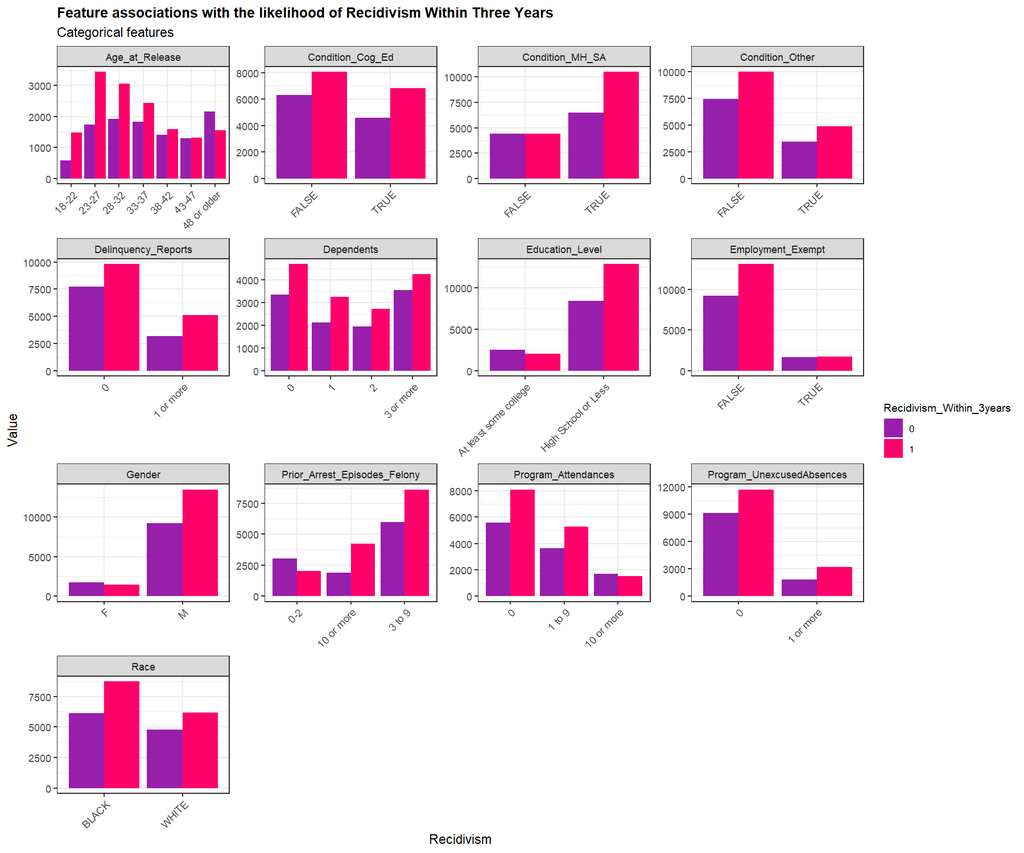

```r
## Count
dat %>%
  select(Recidivism_Within_3years,
         Gender,
         Race,
         Age_at_Release,
         Education_Level,
         Dependents,
         Prior_Arrest_Episodes_Felony,
         Condition_MH_SA,
         Condition_Cog_Ed,
         Condition_Other,
         Delinquency_Reports,
         Program_Attendances,
         Program_UnexcusedAbsences,
         Employment_Exempt) %>%
  gather(Variable, value, -Recidivism_Within_3years) %>%
  count(Variable, value, Recidivism_Within_3years) %>%
    ggplot(., aes(value, n, fill = Recidivism_Within_3years)) +
        geom_bar(position = "dodge", stat="identity") +
        facet_wrap(~Variable, ncol = 4, scales="free") +
        scale_fill_manual(values = palette2) +
        labs(x="Recidivism", y="Value",
             title = "Feature associations with the likelihood of Recidivism Within Three Years",
             subtitle = "Categorical features") +
        theme_bw() +
  theme(plot.title = element_text(size = 12, face = "bold")) +
  theme(legend.title = element_text(size = 9),
        legend.text = element_text(size = 8)) +
        theme(axis.text.x = element_text(angle = 45, hjust = 1))
```

We selected the following continuous variables to build the model and conducted exploratory plots. We chose to treat Prison_Years, Prior_Arrest_Episodes_Misd, Prior_Conviction_Episodes_Felony, and Prior_Conviction_Episodes_Misd as continuous variables.

**Continuous Variables:**

- Supervision_Risk_Score_First
- Percent_Days_Employed
- Prison_Years (Categorical to Continuous)
- Prior_Arrest_Episodes_Misd (Categorical to Continuous)
- Prior_Conviction_Episodes_Felony (Categorical to Continuous)
- Prior_Conviction_Episodes_Misd (Categorical to Continuous)

We respectively visualized average counts and density of non-recidivism and recidivism by categories below. From both sets of plots, we observed that individuals prone to recidivism are generally associated with higher arrest and conviction episodes, while individuals who do not fall into recidivism generally have more stable employment (represented by higher Percent_Days_Employed) or longer prison experience.

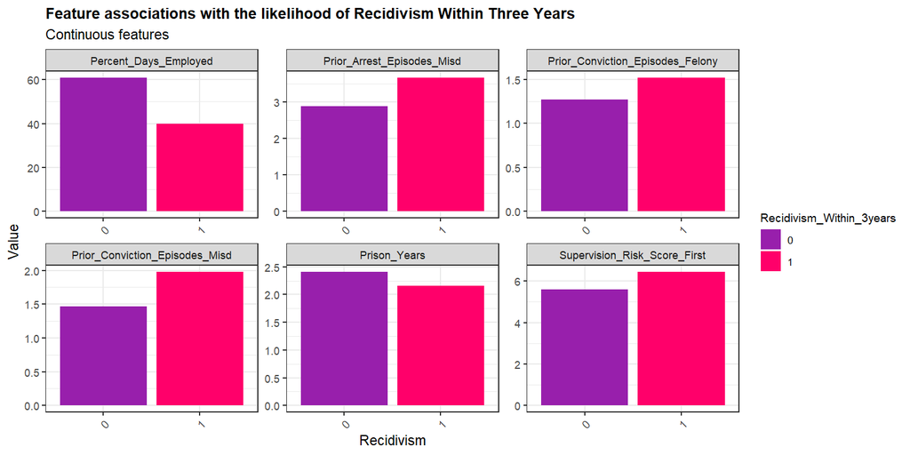

```r
# Transform categorical variables into continuous variables
dat <- dat %>%
  mutate(Percent_Days_Employed = round(Percent_Days_Employed * 100, digit = 2)) %>%
  mutate(Prison_Years = case_when(
    Prison_Years == "Less than 1 year" ~ "1",
    Prison_Years == "1-2 years" ~ "2",
    Prison_Years == "Greater than 2 to 3 years" ~ "3",
    Prison_Years == "More than 3 years" ~ "4")) %>%
  mutate(Prison_Years = as.numeric(Prison_Years)) %>%
  mutate(Prior_Arrest_Episodes_Misd = case_when(
    Prior_Arrest_Episodes_Misd == "6 or more" ~ "6",
    TRUE ~ Prior_Arrest_Episodes_Misd)) %>%
  mutate(Prior_Arrest_Episodes_Misd = as.numeric(Prior_Arrest_Episodes_Misd)) %>%
  mutate(Prior_Conviction_Episodes_Felony = case_when(
    Prior_Conviction_Episodes_Felony == "3 or more" ~ "3",
    TRUE ~ Prior_Conviction_Episodes_Felony)) %>%
  mutate(Prior_Conviction_Episodes_Felony = as.numeric(Prior_Conviction_Episodes_Felony)) %>%
  mutate(Prior_Conviction_Episodes_Misd = case_when(
    Prior_Conviction_Episodes_Misd == "4 or more" ~ "4",
    TRUE ~ Prior_Conviction_Episodes_Misd)) %>%
  mutate(Prior_Conviction_Episodes_Misd = as.numeric(Prior_Conviction_Episodes_Misd))

# Plot continuous variables
## Mean
dat %>%
  select(Supervision_Risk_Score_First,
         Percent_Days_Employed,
         Prison_Years,
         Prior_Arrest_Episodes_Misd,
         Prior_Conviction_Episodes_Felony,
         Prior_Conviction_Episodes_Misd,
         Recidivism_Within_3years) %>%
  filter_all(all_vars(!is.na(.))) %>%
  gather(Variable, value, -Recidivism_Within_3years) %>%
    ggplot(aes(Recidivism_Within_3years, value, fill=Recidivism_Within_3years)) +
      geom_bar(position = "dodge", stat = "summary", fun = "mean") +
      facet_wrap(~Variable, scales = "free") +
      scale_fill_manual(values = palette2) +
      labs(x="Recidivism", y="Value",
           title = "Feature associations with the likelihood of Recidivism Within Three Years",
           subtitle = "Continuous features") +
       theme_bw() +
  theme(plot.title = element_text(size = 12, face = "bold")) +
  theme(legend.title = element_text(size = 9),
        legend.text = element_text(size = 8)) +
        theme(axis.text.x = element_text(angle = 45, hjust = 1))
```

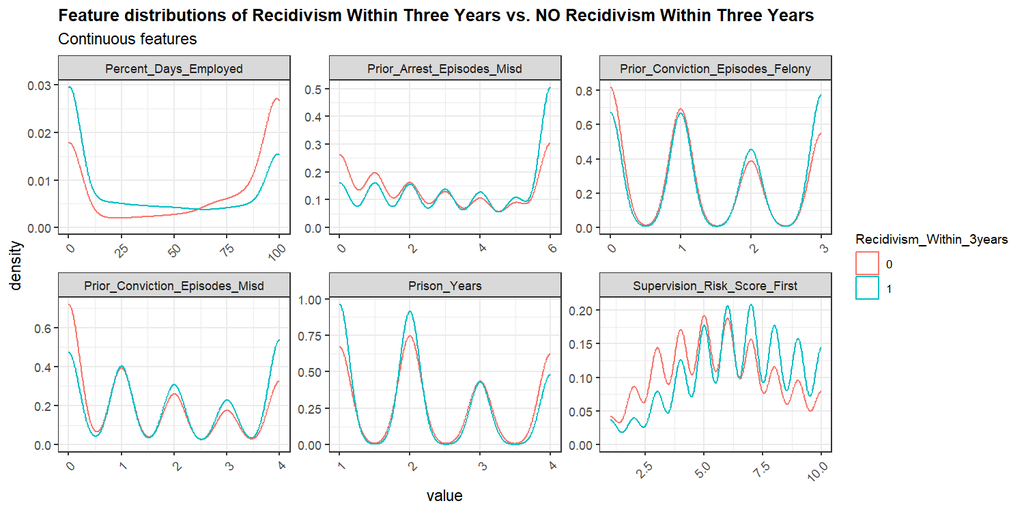

```r
## Density
dat %>%
   select(Supervision_Risk_Score_First,
         Percent_Days_Employed,
         Prison_Years,
         Prior_Arrest_Episodes_Misd,
         Prior_Conviction_Episodes_Felony,
         Prior_Conviction_Episodes_Misd,
         Recidivism_Within_3years) %>%
    filter_all(all_vars(!is.na(.))) %>%
    gather(Variable, value, -Recidivism_Within_3years) %>%
    ggplot() +
    geom_density(aes(value, color=Recidivism_Within_3years), fill = "transparent") +
    facet_wrap(~Variable, scales = "free") +
    scale_fill_manual(values = palette2) +
    labs(title = "Feature distributions of Recidivism Within Three Years vs. NO Recidivism Within Three Years",
         subtitle = "Continuous features") +
  theme_bw() +
  theme(plot.title = element_text(size = 12, face = "bold")) +
  theme(legend.title = element_text(size = 9),
        legend.text = element_text(size = 8)) +
        theme(axis.text.x = element_text(angle = 45, hjust = 1))
```

# Model Develop

We splitted the data into equally-sized training and test datasets, and input all the selected variables into a baseline model (mod1) to conduct backward elimination.

To improve the baseline model, we created four additional iterations. In each round, we examined the statistical significance of each variable and used the model to predict for each individual’s predicted recidivating outcome the 0.5 threshold (assuming that in a normal scenario, an individual’s chance to re-offence or not is equal), and examined the confusion matrix. From there, we evaluated the change of sensitivity in comparison to specificity, and removed variables only if the increase in sensitivity outweighs the decrease in specificity.

```r
# Initial variable selection
## Build dataset
dat <- dat %>%
  select(Gender, Race, Age_at_Release, Education_Level, Dependents, Prior_Arrest_Episodes_Felony,
         Condition_MH_SA, Condition_Cog_Ed, Condition_Other, Delinquency_Reports, Program_Attendances,
         Program_UnexcusedAbsences, Employment_Exempt, Supervision_Risk_Score_First, Percent_Days_Employed,
         Prison_Years, Prior_Arrest_Episodes_Misd, Prior_Conviction_Episodes_Felony, Prior_Conviction_Episodes_Misd,
         Recidivism_Within_3years) %>%
filter_all(all_vars(!is.na(.)))

## Split dataset
set.seed(1)
trainIndex <- createDataPartition(dat$Recidivism_Within_3years, p = .50,
                                  list = FALSE,
                                  times = 1)
dat.train <- dat[trainIndex,]
dat.test  <- dat[-trainIndex,]

## Remove insignificant variables based on sensitivity and specificity
mod1 <- glm(Recidivism_Within_3years ~ .,
                 data = dat.train,
                 na.action = na.exclude,
                 family = binomial("logit"))

testProbs <- data.frame(Outcome = as.factor(dat.test$Recidivism_Within_3years),
                        Probs = predict(mod1, dat.test, type= "response")) %>% ### Test probabilities
  mutate(predOutcome  = as.factor(ifelse(Probs > 0.5 , "1", "0"))) ### Set thresholds
100 * prop.table(table(Observed = testProbs$Outcome, Predicted = testProbs$predOutcome), margin = 1)

### Remove Race
mod2 <- glm(Recidivism_Within_3years ~ . -Race,
                 data = dat.train,
                 na.action = na.exclude,
                 family = binomial("logit"))

testProbs <- data.frame(Outcome = as.factor(dat.test$Recidivism_Within_3years),
                        Probs = predict(mod2, dat.test, type= "response")) %>% ### Test probabilities
  mutate(predOutcome  = as.factor(ifelse(Probs > 0.5 , "1", "0"))) ### Set thresholds
100 * prop.table(table(Observed = testProbs$Outcome, Predicted = testProbs$predOutcome), margin = 1)

### Remove Delinquency_Reports
mod3 <- glm(Recidivism_Within_3years ~ . -Race -Delinquency_Reports,
                 data = dat.train,
                 na.action = na.exclude,
                 family = binomial("logit"))

testProbs <- data.frame(Outcome = as.factor(dat.test$Recidivism_Within_3years),
                        Probs = predict(mod3, dat.test, type= "response")) %>% ### Test probabilities
  mutate(predOutcome  = as.factor(ifelse(Probs > 0.5 , "1", "0"))) ### Set thresholds
100 * prop.table(table(Observed = testProbs$Outcome, Predicted = testProbs$predOutcome), margin = 1)

### Remove Employment_Exempt
mod4 <- glm(Recidivism_Within_3years ~ . -Race -Delinquency_Reports -Employment_Exempt,
                 data = dat.train,
                 na.action = na.exclude,
                 family = binomial("logit"))

testProbs <- data.frame(Outcome = as.factor(dat.test$Recidivism_Within_3years),
                        Probs = predict(mod4, dat.test, type= "response")) %>% ### Test probabilities
  mutate(predOutcome  = as.factor(ifelse(Probs > 0.5 , "1", "0"))) ### Set thresholds
100 * prop.table(table(Observed = testProbs$Outcome, Predicted = testProbs$predOutcome), margin = 1)

### Remove Prior_Conviction_Episodes_Felony
mod5 <- glm(Recidivism_Within_3years ~ . -Race -Delinquency_Reports -Employment_Exempt
            -Prior_Conviction_Episodes_Felony,
                 data = dat.train,
                 na.action = na.exclude,
                 family = binomial("logit"))

testProbs <- data.frame(Outcome = as.factor(dat.test$Recidivism_Within_3years),
                        Probs = predict(mod5, dat.test, type= "response")) %>% ### Test probabilities
  mutate(predOutcome  = as.factor(ifelse(Probs > 0.5 , 1, 0))) ### Set thresholds
100 * prop.table(table(Observed = testProbs$Outcome, Predicted = testProbs$predOutcome), margin = 1)
```

[output not shown]

# Result Interpretation

Key outcomes of the final model results suggest that on average, when all else is equal, individuals who are released at higher age ranks (in comparison to individuals aged 18-22), with a higher educational level, with cognitive education condition, with longer program or prison attendance, with higher percent of employed days generally have lower odds in committing recidivism in comparison to respective categorical variable’s reference level. However, on average, when all else is equal, individuals who identify as gender male, with dependents, with higher episodes (for any type of crime), with mental health/substance abuse or other conditions, with higher unexcused absence from programs, and with higher supervision scores generally have higher odds in committing recidivism in comparison to respective categorical variable’s reference level.

Regardless of one’s crime record, by examining demographic and socio-economic characteristics only, we may conclude that a young (18-22) male with higher dependent burdens, less employment stability, lower education, as well as higher vulnerability to special conditions is most at risk of being predicted as a re-offender.

```r
model_summary <- summary(mod5)$coefficients

model_df <- as.data.frame(model_summary)

# Manually add stars to coefficients based on p-values

model_df$Significance <- ifelse(model_summary[,4] < 0.001, "***",
                          ifelse(model_summary[,4] < 0.01, "**",
                                 ifelse(model_summary[,4] < 0.05, "*", "")))

# Combine Estimate and Significance into a single column for aesthetic purposes
model_df$Estimate <- paste0(sprintf("%.3f", model_df$Estimate),
                            model_df$Significance)

# Now use kable to create the table
kable(model_df[, -5], format = "html", digits = 3, caption = "Summary of Model mod5") %>%
  kable_styling(bootstrap_options = c("striped", "hover", "condensed"), full_width = F) %>%
  column_spec(1, bold = T)
```

Summary of Model mod5

|  | Estimate | Std. Error | z value | Pr(>\|z\|) |
| --- | --- | --- | --- | --- |
| (Intercept) | 0.043 | 0.130 | 0.331 | 0.741 |
| GenderM | 0.446*** | 0.061 | 7.297 | 0.000 |
| Age_at_Release23-27 | -0.419*** | 0.089 | -4.710 | 0.000 |
| Age_at_Release28-32 | -0.761*** | 0.094 | -8.130 | 0.000 |
| Age_at_Release33-37 | -0.970*** | 0.099 | -9.769 | 0.000 |
| Age_at_Release38-42 | -1.182*** | 0.107 | -11.082 | 0.000 |
| Age_at_Release43-47 | -1.351*** | 0.113 | -12.004 | 0.000 |
| Age_at_Release48 or older | -1.708*** | 0.112 | -15.187 | 0.000 |
| Education_LevelAt least some college | -0.105 | 0.055 | -1.927 | 0.054 |
| Dependents1 | 0.094 | 0.057 | 1.643 | 0.100 |
| Dependents2 | 0.005 | 0.060 | 0.082 | 0.934 |
| Dependents3 or more | 0.048 | 0.053 | 0.909 | 0.363 |
| Prior_Arrest_Episodes_Felony3 to 9 | 0.508*** | 0.058 | 8.816 | 0.000 |
| Prior_Arrest_Episodes_Felony10 or more | 1.043*** | 0.078 | 13.316 | 0.000 |
| Condition_MH_SATRUE | 0.351*** | 0.046 | 7.617 | 0.000 |
| Condition_Cog_EdTRUE | -0.042 | 0.043 | -0.983 | 0.326 |
| Condition_OtherTRUE | 0.030 | 0.045 | 0.675 | 0.500 |
| Program_Attendances1 to 9 | -0.163*** | 0.048 | -3.389 | 0.001 |
| Program_Attendances10 or more | -0.644*** | 0.072 | -8.973 | 0.000 |
| Program_UnexcusedAbsences1 or more | 0.274*** | 0.060 | 4.597 | 0.000 |
| Supervision_Risk_Score_First | 0.073*** | 0.010 | 6.953 | 0.000 |
| Percent_Days_Employed | -0.011*** | 0.000 | -23.234 | 0.000 |
| Prison_Years | -0.066** | 0.020 | -3.216 | 0.001 |
| Prior_Arrest_Episodes_Misd | 0.078*** | 0.014 | 5.409 | 0.000 |
| Prior_Conviction_Episodes_Misd | 0.097*** | 0.021 | 4.648 | 0.000 |

# ROC Curve

We then plotted the Receiver Operating Characteristic (ROC) curve below and visualized the overall model performance as well as at each probability threshold. The ROC curve lie above the y=x line with an area under curve (AUC) equals to 0.74, suggesting that the model performs much better than a coin flip.

```r
pROC::auc(testProbs$Outcome, testProbs$Probs)
```

```
## Area under the curve: 0.7437
```

```r
# function from the book
iterateThresholds <- function(data, observedClass, predictedProbs, group) {
  observedClass <- enquo(observedClass)
  predictedProbs <- enquo(predictedProbs)
  group <- enquo(group)
  x = .01
  all_prediction <- data.frame()

  if (missing(group)) {

    while (x <= 1) {
    this_prediction <- data.frame()

    this_prediction <-
      data %>%
      mutate(predclass = ifelse(!!predictedProbs > x, 1,0)) %>%
      count(predclass, !!observedClass) %>%
      summarize(Count_TN = sum(n[predclass==0 & !!observedClass==0]),
                Count_TP = sum(n[predclass==1 & !!observedClass==1]),
                Count_FN = sum(n[predclass==0 & !!observedClass==1]),
                Count_FP = sum(n[predclass==1 & !!observedClass==0]),
                Rate_TP = Count_TP / (Count_TP + Count_FN),
                Rate_FP = Count_FP / (Count_FP + Count_TN),
                Rate_FN = Count_FN / (Count_FN + Count_TP),
                Rate_TN = Count_TN / (Count_TN + Count_FP),
                Accuracy = (Count_TP + Count_TN) /
                           (Count_TP + Count_TN + Count_FN + Count_FP)) %>%
      mutate(Threshold = round(x,2))

    all_prediction <- rbind(all_prediction,this_prediction)
    x <- x + .01
  }
  return(all_prediction)
  }
  else if (!missing(group)) {
   while (x <= 1) {
    this_prediction <- data.frame()

    this_prediction <-
      data %>%
      mutate(predclass = ifelse(!!predictedProbs > x, 1,0)) %>%
      group_by(!!group) %>%
      count(predclass, !!observedClass) %>%
      summarize(Count_TN = sum(n[predclass==0 & !!observedClass==0]),
                Count_TP = sum(n[predclass==1 & !!observedClass==1]),
                Count_FN = sum(n[predclass==0 & !!observedClass==1]),
                Count_FP = sum(n[predclass==1 & !!observedClass==0]),
                Rate_TP = Count_TP / (Count_TP + Count_FN),
                Rate_FP = Count_FP / (Count_FP + Count_TN),
                Rate_FN = Count_FN / (Count_FN + Count_TP),
                Rate_TN = Count_TN / (Count_TN + Count_FP),
                Accuracy = (Count_TP + Count_TN) /
                           (Count_TP + Count_TN + Count_FN + Count_FP)) %>%
      mutate(Threshold = round(x, 2))

    all_prediction <- rbind(all_prediction, this_prediction)
    x <- x + .01
  }
  return(all_prediction)
  }
}
```

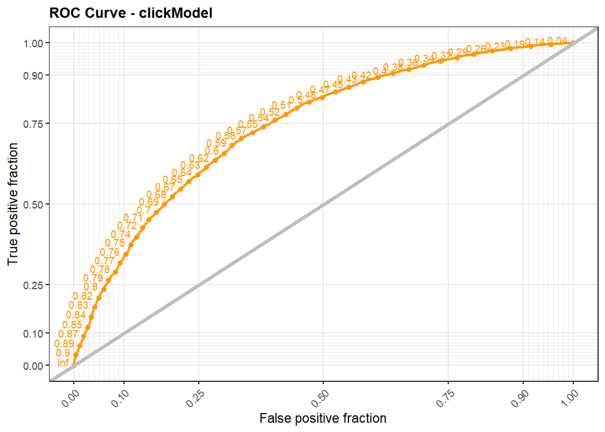

```r
ggplot(testProbs, aes(d = as.numeric(Outcome), m = Probs)) +
  geom_roc(n.cuts = 50, labels = T, labelsize = 3,labelround = 2,colour = "#FE9900") +
  style_roc(theme = theme_grey) +
  geom_abline(slope = 1, intercept = 0, size = 1.5, color = 'grey') +
  labs(title = "ROC Curve - clickModel") +
    theme_bw() +
  theme(plot.title = element_text(size = 12, face = "bold")) +
  theme(legend.title = element_text(size = 9),
        legend.text = element_text(size = 8)) +
        theme(axis.text.x = element_text(angle = 45, hjust = 1))
```

The model’s sensitivity and specificity at each threshold is illustrated in the following plot.

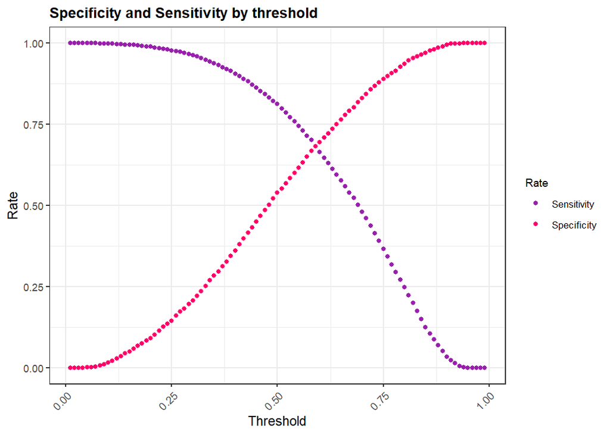

```r
# choose the threshold:
# baseline (threshold =0.5): sensitivity = 0.8120290, specificity = 0.5394175
# a better one: sensitivity increase > specificity decrease
whichThreshold <-
  iterateThresholds(data=testProbs, observedClass = Outcome, predictedProbs = Probs)

whichThreshold.nocost <- whichThreshold %>%
  dplyr::select(Rate_TP, Rate_TN, Threshold)%>%
  rename(Sensitivity = Rate_TP, Specificity = Rate_TN)%>%
  mutate(
    Sensitivity.change = Sensitivity - 0.8120290,
    Specificity.change = Specificity - 0.5394175
  )%>%
  mutate(change.sum = Sensitivity.change + Specificity.change)

#plot sensitivity and specificity
whichThreshold.nocost %>%
  select(Sensitivity, Specificity, Threshold)%>%
  gather(Variable, Rate, -Threshold) %>%
  ggplot(.,aes(Threshold, Rate, colour = Variable)) +
  geom_point() +
  scale_colour_manual(values = palette2) +
  labs(title = "Specificity and Sensitivity by threshold",
       y = "Rate") +
  guides(colour=guide_legend(title = "Rate"))+
        theme_bw() +
  theme(plot.title = element_text(size = 12, face = "bold")) +
  theme(legend.title = element_text(size = 9),
        legend.text = element_text(size = 8)) +
        theme(axis.text.x = element_text(angle = 45, hjust = 1))
```

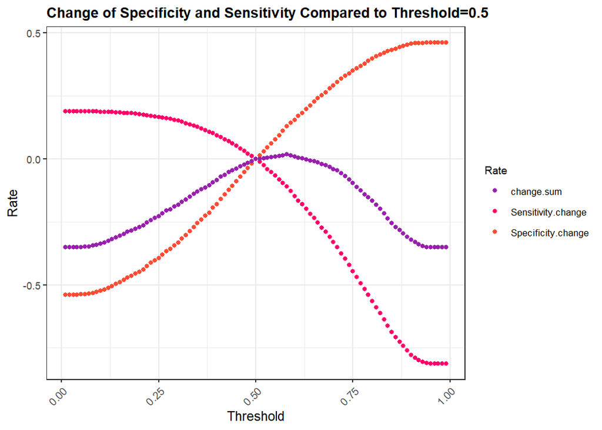

```r
#plot the changes
whichThreshold.nocost %>%
  select(Sensitivity.change, Specificity.change, change.sum, Threshold)%>%
  gather(Variable, Rate, -Threshold) %>%
  ggplot(.,aes(Threshold, Rate, colour = Variable)) +
  geom_point() +
  scale_colour_manual(values = palette3) +
  labs(title = "Change of Specificity and Sensitivity Compared to Threshold=0.5",
       y = "Rate") +
  guides(colour=guide_legend(title = "Rate"))+
        theme_bw() +
  theme(plot.title = element_text(size = 12, face = "bold")) +
  theme(legend.title = element_text(size = 9),
        legend.text = element_text(size = 8)) +
        theme(axis.text.x = element_text(angle = 45, hjust = 1))
```

```r
# table the change
whichThreshold.nocost %>%
  select(Threshold, Sensitivity.change, Specificity.change, change.sum)%>%
  kable() %>%
    kable_styling(bootstrap_options = c("striped", "hover"),
                full_width = T) %>%
  column_spec(1:3, extra_css = "text-align: left;")
```

| Threshold | Sensitivity.change | Specificity.change | change.sum |
| --- | --- | --- | --- |
| 0.01 | 0.1879710 | -0.5394175 | -0.3514465 |
| 0.02 | 0.1879710 | -0.5394175 | -0.3514465 |
| 0.03 | 0.1879710 | -0.5394175 | -0.3514465 |
| 0.04 | 0.1878340 | -0.5394175 | -0.3515835 |
| 0.05 | 0.1878340 | -0.5380583 | -0.3502243 |
| 0.06 | 0.1876970 | -0.5374758 | -0.3497788 |
| 0.07 | 0.1876970 | -0.5359224 | -0.3482254 |
| 0.08 | 0.1874230 | -0.5324272 | -0.3450042 |
| 0.09 | 0.1871490 | -0.5287379 | -0.3415889 |
| 0.10 | 0.1867380 | -0.5231068 | -0.3363689 |
| 0.11 | 0.1859159 | -0.5188350 | -0.3329191 |
| 0.12 | 0.1853679 | -0.5118447 | -0.3264768 |
| 0.13 | 0.1850939 | -0.5046602 | -0.3195663 |
| 0.14 | 0.1839979 | -0.4957282 | -0.3117303 |
| 0.15 | 0.1831758 | -0.4891262 | -0.3059504 |
| 0.16 | 0.1824908 | -0.4817476 | -0.2992568 |
| 0.17 | 0.1818058 | -0.4722330 | -0.2904273 |
| 0.18 | 0.1804357 | -0.4644660 | -0.2840303 |
| 0.19 | 0.1782436 | -0.4566991 | -0.2784554 |
| 0.20 | 0.1772846 | -0.4481554 | -0.2708708 |
| 0.21 | 0.1745445 | -0.4388350 | -0.2642905 |
| 0.22 | 0.1729004 | -0.4252427 | -0.2523423 |
| 0.23 | 0.1702973 | -0.4133981 | -0.2431007 |
| 0.24 | 0.1679683 | -0.4033010 | -0.2353327 |
| 0.25 | 0.1653652 | -0.3943690 | -0.2290038 |
| 0.26 | 0.1630361 | -0.3796117 | -0.2165756 |
| 0.27 | 0.1609810 | -0.3671845 | -0.2062035 |
| 0.28 | 0.1575559 | -0.3576699 | -0.2001141 |
| 0.29 | 0.1544048 | -0.3440777 | -0.1896729 |
| 0.30 | 0.1508426 | -0.3324272 | -0.1815846 |

[output cut: 69 more lines]

```r
# -> result: threshold 0.5
```

# Confusion Matrix

The confusion matrix at threshold = 0.5 is shown below. Here’s what each cell means:

- Cell corresponding to 0 under both Reference and Prediction: True Negative, an individual is predicted not to recidivate and indeed does not recidivate.
- Cell corresponding to 0 under Reference but 1 under Prediction: False Positive, an individual is predicted to recidivate but does not actually recidivate.
- Cell corresponding to 1 under Reference but 0 under Prediction: False Negative, an individual is predicted not to recidivate but then does recidivate.
- Cell corresponding to 1 under both Reference and Prediction: True Positive, an individual is predicted to recidivate and then does recidivate.

```r
testProbs <-
  testProbs %>%
  mutate(predOutcome  = as.factor(ifelse(testProbs$Probs > 0.5 , 1, 0)))

caret::confusionMatrix(testProbs$predOutcome, testProbs$Outcome,
                       positive = "1")
```

```
## Confusion Matrix and Statistics
##
##           Reference
## Prediction    0    1
##          0 2778 1372
##          1 2372 5927
##
##                Accuracy : 0.6993
##                  95% CI : (0.6911, 0.7073)
##     No Information Rate : 0.5863
##     P-Value [Acc > NIR] : < 0.00000000000000022
##
##                   Kappa : 0.3618
##
##  Mcnemar's Test P-Value : < 0.00000000000000022
##
##             Sensitivity : 0.8120
##             Specificity : 0.5394
##          Pos Pred Value : 0.7142
##          Neg Pred Value : 0.6694
##              Prevalence : 0.5863
##          Detection Rate : 0.4761
##    Detection Prevalence : 0.6666
##       Balanced Accuracy : 0.6757
##
##        'Positive' Class : 1
##
```

The model has an overall accuracy of 0.699, meaning that the model correctly predicts approximately 70% out of all instances.

Sensitivity is the true positive rate, calculated as True Positive / True Positive + False Negative. This model has a 81.2% sensitivity, indicating that the model captures 81.2% true cases of recidivism instances out of all cases where re-offence occurred.

Specificity is the true negative rate, calculated as True Negative / True Negative + False Positive. The model has a 53.9% specificity. indicating that the model captures 53.9% true cases whereby an individual did not recidivate out of all cases where no re-offence occurred.

# Error and Equity Discussion

We used bar charts to visualize statistics by race and race-gender pairs. From the chart evaluating model performance by race, we note the following observations: - Overall accuracy is approximately the same for black and white race groups.

- False positive rate (0.51) and True positive rate (0.83) of the black community surpasses the white community, indicating that the model performs better at capturing black re-offenders, it simultaneously has higher errors in misclassifying black individuals as re-offenders and overpredicts recidivism instances in this particular group.
- Comparatively, both the false negative rate (0.22) and true negative rate (0.61) of the white community surpasses the black community, indicating that the model has lower misclassification errors among white individuals, however, it is more lenient towards true re-offenders as well, thus leading to underprediction and potential social risks.

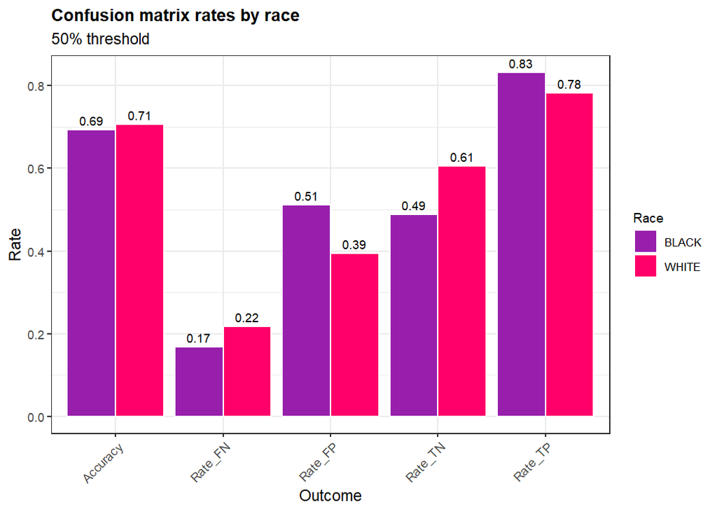

```r
testProbs2 <-
  data.frame(class = as.numeric(as.character(dat.test$Recidivism_Within_3years)),
             probs = predict(mod5, dat.test, type = "response"),
             Race = dat.test$Race,
             Gender = dat.test$Gender)%>%
  mutate(Race.Gender = paste(Race, Gender, sep = "-"))

# plot error by race
testProbs.thresholds <-
  iterateThresholds(data=testProbs2, observedClass = class,
                    predictedProbs = probs, group = Race)

filter(testProbs.thresholds, Threshold == .5)  %>%
  dplyr::select(Accuracy, Race, starts_with("Rate")) %>%
  gather(Variable, Value, -Race) %>%
  ggplot(aes(Variable, Value, fill = Race)) +
  geom_bar(aes(fill = Race), position = "dodge", stat = "identity",colour = "white") +
  geom_text(aes(label = sprintf("%.2f", Value)),                      # Add labels
            position = position_dodge(width = 0.9), vjust = -0.5, size = 3) +
  scale_fill_manual(values = palette2) +
  labs(title="Confusion matrix rates by race",
       subtitle = "50% threshold", x = "Outcome",y = "Rate") +
  theme(axis.text.x = element_text(angle = 45, hjust = 1)) +
        theme_bw() +
  theme(plot.title = element_text(size = 12, face = "bold")) +
  theme(legend.title = element_text(size = 9),
        legend.text = element_text(size = 8)) +
        theme(axis.text.x = element_text(angle = 45, hjust = 1))
```

From the bar chart plotting for race-gender pairs, the following observations are made:

- By fixing the effect of race and looking at gender only, females tend to have higher false negative rate and true negative rate compared to males, while males generally have higher false positive rate and true positive rate compared to females.
- White female surpasses other race-gender groups in both false negative rate (0.37) and true negative rate (0.73), suggesting that this group faces least misclassification error to be predicted for recidivism, however, the model also gives them the highest leniency that potentially let go of criminals.
- On the other hand, the false positive rate (0.54) and true positive rate (0.84) associated with the black male group tops all other categories, indicating that the model performs better at identifying black male re-offenders, but simultaneously mislabel more individuals from this group as potential criminals.

Although race is not an input variable used in the model, our model continues to display explicit biases by over predicting recidivism among the black community, particularly affecting the black males. Despite an overall 81.2% sensitivity, the model nonetheless poses key equity challenges.

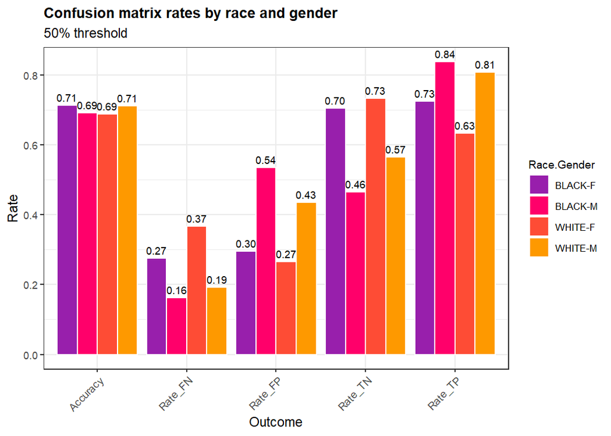

```r
# plot error by race and gender
testProbs.thresholds <-
  iterateThresholds(data=testProbs2, observedClass = class,
                    predictedProbs = probs, group = Race.Gender)

filter(testProbs.thresholds, Threshold == .5)  %>%
  dplyr::select(Accuracy, Race.Gender, starts_with("Rate")) %>%
  gather(Variable, Value, -Race.Gender) %>%
  ggplot(aes(Variable, Value, fill = Race.Gender)) +
  geom_bar(aes(fill = Race.Gender), position = "dodge", stat = "identity",colour = "white") +
  geom_text(aes(label = sprintf("%.2f", Value)),
            position = position_dodge(width = 0.9), vjust = -0.5, size = 3) +
  scale_fill_manual(values = palette4) +
  labs(title="Confusion matrix rates by race and gender",
       subtitle = "50% threshold", x = "Outcome",y = "Rate") +
  theme(axis.text.x = element_text(angle = 45, hjust = 1)) +
        theme_bw() +
  theme(plot.title = element_text(size = 12, face = "bold")) +
  theme(legend.title = element_text(size = 9),
        legend.text = element_text(size = 8)) +
        theme(axis.text.x = element_text(angle = 45, hjust = 1))
```

# Cost-Benifit Analysis

We estimated the following list of cost associated with judicial procedures:

- Average cost of keeping someone in prison for a year: $40,000
- Average cost of arrest and trial for a recidivist: $10,000
- Average cost of a crime committed by a recidivist: $50,000
- Average compensation for wrongful incarceration: $50,000

Based on the list, we calculated the cost associated with true negative, true positive, false negative, and false positive incidents below:

- **True negative Cost**: “An individual is predicted not to recidivate and indeed does not recidivate.” - No cost
- **True positive Cost**: “An individual is predicted to recidivate and then does recidivate.” - $40k
- **False negative Cost**: “An individual is predicted not to recidivate but then does recidivate.” - $100k
- **False positive Cost**: “An individual is predicted to recidivate but does not actually recidivate.” - $50k

By aggregating and plotting all forms of cost at each threshold, we estimated that the lowest sum of cost occurs at threshold = 0.50.

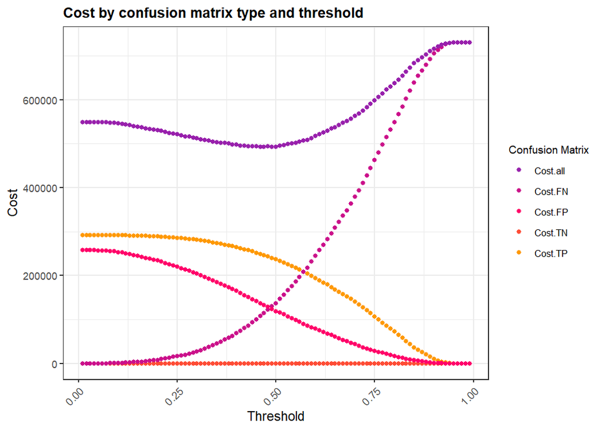

```r
whichThreshold.cost <- whichThreshold %>%
  dplyr::select(starts_with("Count"), Threshold) %>%
  mutate(Cost.TN = Count_TN*0,
         Cost.TP = Count_TP*40,
         Cost.FN = Count_FN*100,
         Cost.FP = Count_FP*50,
         Cost.all = Cost.TN + Cost.TP + Cost.FN + Cost.FP)%>%
  select(starts_with("Cost"), Threshold)%>%
  gather(Variable, Cost, -Threshold)

whichThreshold.cost %>%
  ggplot(.,aes(Threshold, Cost, colour = Variable)) +
  geom_point() +
  scale_colour_manual(values = palette5) +
  labs(title = "Cost by confusion matrix type and threshold",
       y = "Cost") +
  guides(colour=guide_legend(title = "Confusion Matrix"))+
        theme_bw() +
  theme(plot.title = element_text(size = 12, face = "bold")) +
  theme(legend.title = element_text(size = 9),
        legend.text = element_text(size = 8)) +
        theme(axis.text.x = element_text(angle = 45, hjust = 1))
```

```r
threshold.cost <- whichThreshold.cost%>%
  filter(Variable == 'Cost.all')

#-> lowest cost when threshold = 0.50
```

# Conclusion

**Limitations and Restrictions:**

- Although race is not a variable built into the model, we find that at the best threshold, the model is still racially biased.
- The model is biased between genders, too.
- With the aggregated effect of race-gender, the model poses black males at risk particularly.
- Nonetheless, there are restrictions to the model because it is built upon data records of the justice department, whereby incidents of arrest, convictions, mandatory program attendance, as well as captured recidivism cases themselves, are all highly dependent on existing biases.

**Recommendations on how the model may be used:**

- The model can be referenced as a case study on how algorithms are not useful tools in ruling justice decisions.
- For contexts in which the justice system is obliged to implement an algorithm aid due to staff shortage or other conditions, training programs should be established to help staff wisely use algorithm tools and discern biases.
- Policy makers should also continuously seek to address biases in existing algorithm tools used in criminal justice contexts, and rectify biases present in training data for justice algorithms.

# References

- Steif, Ken. Public policy analytics code and context for data science in government. Boca Raton: CRC Press, 2021.
- Angwin, Julia, et al. “Machine Bias.” ProPublica, May 23, 2016. https://www.propublica.org/article/machine-bias-risk-assessments-in-criminal-sentencing.